# Céllövészet

## Feladat

Ketten lőnek célba. Először A lő, és a találatának valószínűsége 60%. Ezután lő B, és (A találatától függetlenül) 50%-os valószínűséggel eltalálja a céltáblát.

Jelentse ξ a találatok számát!

Adják meg ξ

- lehetséges értékeit,
- valószínűségeloszlását,
- várható értékét
- és szórását!

## Lehetséges értékek?

## Értékek (x<sub>i</sub>)

| x<sub>i</sub> | p<sub>i</sub> |
| --- | --- |
| 0 | ? |
| 1 | ? |
| 2 | ? |

Lehetséges, hogy

- egyik sem talál (ξ = 0)
- csak az egyik talál (ξ = 1)
- mindkettő talál (ξ = 2)

## Valószínűségek?

## Valószínűségek

| x<sub>i</sub> | p<sub>i</sub> |
| --- | --- |
| 0 | ? |
| 1 | ? |
| 2 | ? |

## Valószínűségek

| x<sub>i</sub> | p<sub>i</sub> |
| --- | --- |
| 0 | (1 - 0.6)*(1 - 0.5) |
| 1 | ? |
| 2 | ? |

Független események:

- A nem talál: \(P(\overline{A})=1-0,6\)
- B nem talál: \(P(\overline{B})=1-0,5\)
- Mivel független: \(P(\overline{A}*\overline{B})=P(\overline{A})*P(\overline{B})\)

## Valószínűségek

| x<sub>i</sub> | p<sub>i</sub> |
| --- | --- |
| 0 | 0.2 |
| 1 | ? |
| 2 | ? |

## Valószínűségek

| x<sub>i</sub> | p<sub>i</sub> |
| --- | --- |
| 0 | 0.2 |
| 1 | 0.6 * (1 - 0.5) + (1 - 0.6) * 0.5 |
| 2 | ? |

Független események:

- A talál és B nem talál: \(P(A*\overline{B})=P(A)*P(\overline{B})\)
- A nem talál és B talál: \(P(\overline{A}*B)=P(\overline{A})*P(B)\)
- Ezek egymást kölcsönösen kizáró alternatívák: összeadódnak

## Valószínűségek

| x<sub>i</sub> | p<sub>i</sub> |
| --- | --- |
| 0 | 0.2 |
| 1 | 0.5 |
| 2 | ? |

## Valószínűségek

| x<sub>i</sub> | p<sub>i</sub> |
| --- | --- |
| 0 | 0.2 |
| 1 | 0.5 |
| 2 | 0.6*0.5 |

Független események:

- A talál és B talál: \(P(A*B)=P(A)*P(B)\)

## Valószínűségek

| x<sub>i</sub> | p<sub>i</sub> |
| --- | --- |
| 0 | 0.2 |
| 1 | 0.5 |
| 2 | 0.3 |

Figyeljék meg, hogy az összegük ebben az esetben is 1!

## Várható érték?

## Várható érték

| x<sub>i</sub> | 0 | 1 | 2 |
| --- | --- | --- | --- |
| p<sub>i</sub> | 0.2 | 0.5 | 0.3 |

\[E(\xi)=\sum_{i=1}^{n}x_i*p_i\]

## Várható érték

| x<sub>i</sub> | 0 | 1 | 2 |
| --- | --- | --- | --- |
| p<sub>i</sub> | 0.2 | 0.5 | 0.3 |

\[E(\xi)=0*0,2+1*0,5+2*0,3\]

## Várható érték

| x<sub>i</sub> | 0 | 1 | 2 |
| --- | --- | --- | --- |
| p<sub>i</sub> | 0.2 | 0.5 | 0.3 |

\[E(\xi)=0+0,5+0,6=1,1\]

## Szórás?

## Szórás

| x<sub>i</sub> | 0 | 1 | 2 |
| --- | --- | --- | --- |
| p<sub>i</sub> | 0.2 | 0.5 | 0.3 |

Első lépés ξ második momentumának kiszámítása: \[E(\xi^2)=\sum_{i=1}^{n}x_i^2*p_i\]

## Szórás

| x<sub>i</sub> | 0 | 1 | 2 |
| --- | --- | --- | --- |
| p<sub>i</sub> | 0.2 | 0.5 | 0.3 |

Első lépés ξ második momentumának kiszámítása: \[E(\xi^2)=0^2*0,2+1^2*0,5+2^2*0,3\]

## Szórás

| x<sub>i</sub> | 0 | 1 | 2 |
| --- | --- | --- | --- |
| p<sub>i</sub> | 0.2 | 0.5 | 0.3 |

Első lépés ξ második momentumának kiszámítása: \[E(\xi^2)=0+0,5+1,2=1,7\]

## Szórás

Ezután jöhet a szórás kiszámítása: \[D(\xi)=\sqrt{E(\xi^2)-E^2(\xi)}\]

## Szórás

Ezután jöhet a szórás kiszámítása: \[D(\xi)=\sqrt{1,7-1,1^2}\]

## Szórás

Ezután jöhet a szórás kiszámítása: \[D(\xi)=\sqrt{1,7-1,21}=\sqrt{0,49}=0,7\]

[Katt!](https://morauszkia.shinyapps.io/variables/)

## Ábrázolás

## Hisztogram

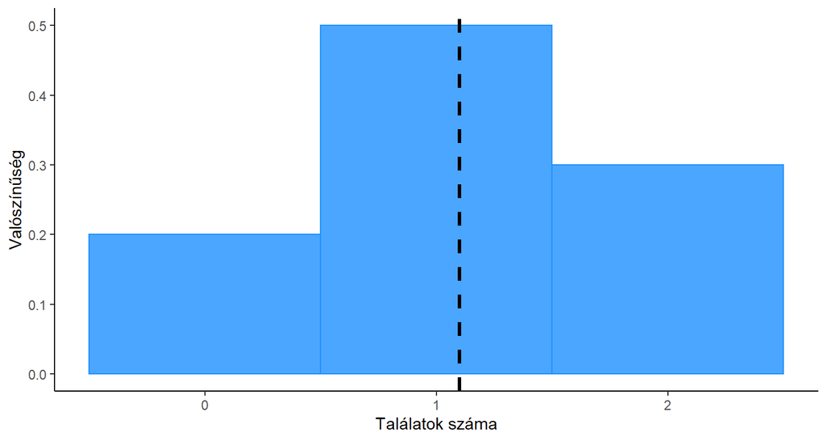

(A szaggatott vonal csak az illusztráció kedvéért van ott, nem kötelező része a hisztogramnak)

## Eloszlásfüggvény

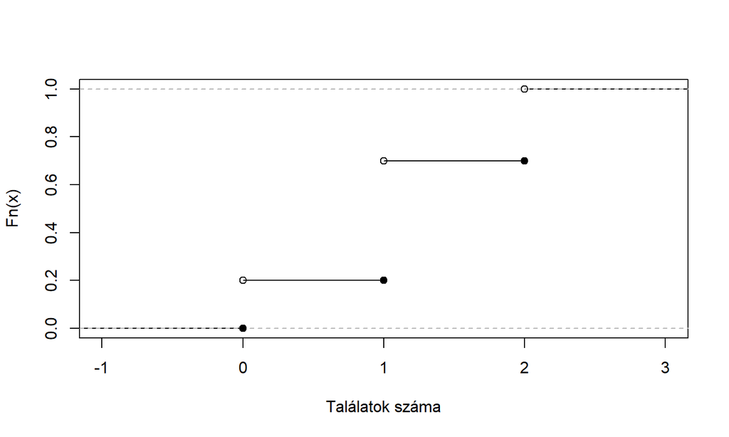